# Programming with models: Inspecting model structure

BayesComp 2020 short course

NIMBLE Development Team

# Running example: the litters model (reparameterized)

Now let’s explore how to understand the dependence structure of a model. The model is a directed acyclic graph, after all, so we should be able to work with that graph structure.

We’ll work with a different parameterization of the beta distribution to be able to illustrate additional concepts.

```r
littersCode <- nimbleCode({
  for (i in 1:G) {
     for (j in 1:N) {
        # likelihood (data model)
        r[i,j] ~ dbin(p[i,j], n[i,j])
        # latent process (random effects)
        # note use of alternative parameterization and named parameters
        p[i,j] ~ dbeta(mean = mu[i], sd = sigma[i])
     }
     # prior for hyperparameters
     mu[i] ~ dflat()
     sigma[i] ~ dunif(0, 100)
   }
})
```

```r
G <- 2
N <- 16
n <- matrix(c(13, 12, 12, 11, 9, 10,
              9, 9, 8, 11, 8, 10, 13, 10, 12, 9, 10, 9, 10, 5, 9, 9, 13,
              7, 5, 10, 7, 6, 10, 10, 10, 7), nrow = 2)
r <- matrix(c(13, 12, 12, 11, 9, 10, 9, 9, 8, 10, 8, 9,
     12, 9, 11, 8, 9, 8, 9, 4, 8, 7, 11, 4, 4, 5, 5, 3, 7, 3, 7, 0),
     nrow = 2)

littersConstants <- list(G = G, N = N, n = n)
littersData <- list(r = r)
littersInits <- list(mu = rep(0.5, 2), sigma = rep(3, 2))

## create the NIMBLE model object
model <- nimbleModel(littersCode,
          data = littersData, constants = littersConstants, inits = littersInits)
```

```
## defining model...
```

```
## building model...
```

```
## setting data and initial values...
```

```
## running calculate on model (any error reports that follow may simply reflect missing values in model variables) ...
## checking model sizes and dimensions... This model is not fully initialized. This is not an error. To see which variables are not initialized, use model$initializeInfo(). For more information on model initialization, see help(modelInitialization).
## model building finished.
```

# Nodes and variables

The parameters and data in a model are represented as nodes in a graph. Here we define some terms:

- parameter: an unknown quantity in the model that is represented as a random variable and will generally be estimated in an algorithm, e.g. `mu[1]` in the (reparameterized) litters model
- data: a known quantity in a model, also represented as a random variable, e.g., `r[1, 1], ..., r[1, 16], ...` in the litters model
- constants: other fixed quantities involved in the model, e.g., `G` in the litters model
- node: an element in the model graph representing data, parameter, or a deterministic quantity that is a function of other quantities in the model, e.g., `mu[1]`, `mu[2]`, or `p[1, 5]` in the litters model
- variable: a collection of one or more nodes with the same name, e.g., *mu* or *r* in the litters model.

Note, if we have a multivariate distribution, then the node includes all of the elements: suppose we define `mu[1:2]` to have a bivariate normal prior; then `mu[1:2]` is the node and `mu` is the variable.

# Querying nodes and variables

NIMBLE provides users and programmers with the ability to get information about the nodes and variables in the model and the relationships amongst them.

What are the nodes in the model? What are the dependencies of a given node (this is information used in many algorithms)?

```r
nodes <- model$getNodeNames()
nodes[1:11]
```

```
##  [1] "mu[1]"
##  [2] "mu[2]"
##  [3] "sigma[1]"
##  [4] "sigma[2]"
##  [5] "lifted_mu_oBi_cB_tothe_2_times__oP1_minus_mu_oBi_cB_cP_over_sigma_oBi_cB_tothe_2_minus_mu_oBi_cB_L4[1]"
##  [6] "lifted_mu_oBi_cB_times__oP1_minus_mu_oBi_cB_cP_tothe_2_over_sigma_oBi_cB_tothe_2_plus_mu_oBi_cB_minus_1_L4[1]"
##  [7] "lifted_mu_oBi_cB_tothe_2_times__oP1_minus_mu_oBi_cB_cP_over_sigma_oBi_cB_tothe_2_minus_mu_oBi_cB_L4[2]"
##  [8] "lifted_mu_oBi_cB_times__oP1_minus_mu_oBi_cB_cP_tothe_2_over_sigma_oBi_cB_tothe_2_plus_mu_oBi_cB_minus_1_L4[2]"
##  [9] "p[1, 1]"
## [10] "p[1, 2]"
## [11] "p[1, 3]"
```

```r
top <- model$getNodeNames(topOnly = TRUE)
top
```

```
## [1] "mu[1]"    "mu[2]"    "sigma[1]" "sigma[2]"
```

```r
muDeps <- model$getDependencies('mu')
muDeps[1:11]
```

```
##  [1] "mu[1]"
##  [2] "mu[2]"
##  [3] "lifted_mu_oBi_cB_tothe_2_times__oP1_minus_mu_oBi_cB_cP_over_sigma_oBi_cB_tothe_2_minus_mu_oBi_cB_L4[1]"
##  [4] "lifted_mu_oBi_cB_times__oP1_minus_mu_oBi_cB_cP_tothe_2_over_sigma_oBi_cB_tothe_2_plus_mu_oBi_cB_minus_1_L4[1]"
##  [5] "lifted_mu_oBi_cB_tothe_2_times__oP1_minus_mu_oBi_cB_cP_over_sigma_oBi_cB_tothe_2_minus_mu_oBi_cB_L4[2]"
##  [6] "lifted_mu_oBi_cB_times__oP1_minus_mu_oBi_cB_cP_tothe_2_over_sigma_oBi_cB_tothe_2_plus_mu_oBi_cB_minus_1_L4[2]"
##  [7] "p[1, 1]"
##  [8] "p[1, 2]"
##  [9] "p[1, 3]"
## [10] "p[1, 4]"
## [11] "p[1, 5]"
```

# Data nodes

```r
model$getNodeNames(dataOnly = TRUE)
```

```
##  [1] "r[1, 1]"  "r[1, 2]"  "r[1, 3]"  "r[1, 4]"  "r[1, 5]"  "r[1, 6]"
##  [7] "r[1, 7]"  "r[1, 8]"  "r[1, 9]"  "r[1, 10]" "r[1, 11]" "r[1, 12]"
## [13] "r[1, 13]" "r[1, 14]" "r[1, 15]" "r[1, 16]" "r[2, 1]"  "r[2, 2]"
## [19] "r[2, 3]"  "r[2, 4]"  "r[2, 5]"  "r[2, 6]"  "r[2, 7]"  "r[2, 8]"
## [25] "r[2, 9]"  "r[2, 10]" "r[2, 11]" "r[2, 12]" "r[2, 13]" "r[2, 14]"
## [31] "r[2, 15]" "r[2, 16]"
```

```r
model$isData('r')
```

```
##  [1] TRUE TRUE TRUE TRUE TRUE TRUE TRUE TRUE TRUE TRUE TRUE TRUE TRUE TRUE
## [15] TRUE TRUE TRUE TRUE TRUE TRUE TRUE TRUE TRUE TRUE TRUE TRUE TRUE TRUE
## [29] TRUE TRUE TRUE TRUE
```

```r
## parameters (including imputed data)
model$getNodeNames(stochOnly = TRUE, includeData = FALSE)
```

```
##  [1] "mu[1]"    "mu[2]"    "sigma[1]" "sigma[2]" "p[1, 1]"  "p[1, 2]"
##  [7] "p[1, 3]"  "p[1, 4]"  "p[1, 5]"  "p[1, 6]"  "p[1, 7]"  "p[1, 8]"
## [13] "p[1, 9]"  "p[1, 10]" "p[1, 11]" "p[1, 12]" "p[1, 13]" "p[1, 14]"
## [19] "p[1, 15]" "p[1, 16]" "p[2, 1]"  "p[2, 2]"  "p[2, 3]"  "p[2, 4]"
## [25] "p[2, 5]"  "p[2, 6]"  "p[2, 7]"  "p[2, 8]"  "p[2, 9]"  "p[2, 10]"
## [31] "p[2, 11]" "p[2, 12]" "p[2, 13]" "p[2, 14]" "p[2, 15]" "p[2, 16]"
```

# More details on querying model structure

There are a variety of options to `getNodeNames()` and `getDependencies` that allow you to fine-tune the information you get.

```r
args(model$getDependencies)
```

```
## function (nodes, omit = character(), self = TRUE, determOnly = FALSE,
##     stochOnly = FALSE, includeData = TRUE, dataOnly = FALSE,
##     includeRHSonly = FALSE, downstream = FALSE, returnType = "names",
##     returnScalarComponents = FALSE)
## NULL
```

```r
args(model$getNodeNames)
```

```
## function (determOnly = FALSE, stochOnly = FALSE, includeData = TRUE,
##     dataOnly = FALSE, includeRHSonly = FALSE, topOnly = FALSE,
##     latentOnly = FALSE, endOnly = FALSE, returnType = "names",
##     returnScalarComponents = FALSE)
## NULL
```

```r
latents <- model$getNodeNames(latentOnly = TRUE, stochOnly = TRUE,
        includeData = FALSE)
latents
```

```
##  [1] "p[1, 1]"  "p[1, 2]"  "p[1, 3]"  "p[1, 4]"  "p[1, 5]"  "p[1, 6]"
##  [7] "p[1, 7]"  "p[1, 8]"  "p[1, 9]"  "p[1, 10]" "p[1, 11]" "p[1, 12]"
## [13] "p[1, 13]" "p[1, 14]" "p[1, 15]" "p[1, 16]" "p[2, 1]"  "p[2, 2]"
## [19] "p[2, 3]"  "p[2, 4]"  "p[2, 5]"  "p[2, 6]"  "p[2, 7]"  "p[2, 8]"
## [25] "p[2, 9]"  "p[2, 10]" "p[2, 11]" "p[2, 12]" "p[2, 13]" "p[2, 14]"
## [31] "p[2, 15]" "p[2, 16]"
```

```r
model$getDependencies(latents, dataOnly = TRUE)
```

```
##  [1] "r[1, 1]"  "r[1, 2]"  "r[1, 3]"  "r[1, 4]"  "r[1, 5]"  "r[1, 6]"
##  [7] "r[1, 7]"  "r[1, 8]"  "r[1, 9]"  "r[1, 10]" "r[1, 11]" "r[1, 12]"
## [13] "r[1, 13]" "r[1, 14]" "r[1, 15]" "r[1, 16]" "r[2, 1]"  "r[2, 2]"
## [19] "r[2, 3]"  "r[2, 4]"  "r[2, 5]"  "r[2, 6]"  "r[2, 7]"  "r[2, 8]"
## [25] "r[2, 9]"  "r[2, 10]" "r[2, 11]" "r[2, 12]" "r[2, 13]" "r[2, 14]"
## [31] "r[2, 15]" "r[2, 16]"
```

```r
model$getNodeNames(dataOnly = TRUE)
```

```
##  [1] "r[1, 1]"  "r[1, 2]"  "r[1, 3]"  "r[1, 4]"  "r[1, 5]"  "r[1, 6]"
##  [7] "r[1, 7]"  "r[1, 8]"  "r[1, 9]"  "r[1, 10]" "r[1, 11]" "r[1, 12]"
## [13] "r[1, 13]" "r[1, 14]" "r[1, 15]" "r[1, 16]" "r[2, 1]"  "r[2, 2]"
## [19] "r[2, 3]"  "r[2, 4]"  "r[2, 5]"  "r[2, 6]"  "r[2, 7]"  "r[2, 8]"
## [25] "r[2, 9]"  "r[2, 10]" "r[2, 11]" "r[2, 12]" "r[2, 13]" "r[2, 14]"
## [31] "r[2, 15]" "r[2, 16]"
```

# Inspecting the model: variables

What are the variables in the model? What information is available about them?

```r
model$getVarNames()
```

```
## [1] "r"
## [2] "lifted_mu_oBi_cB_tothe_2_times__oP1_minus_mu_oBi_cB_cP_over_sigma_oBi_cB_tothe_2_minus_mu_oBi_cB_L4"
## [3] "lifted_mu_oBi_cB_times__oP1_minus_mu_oBi_cB_cP_tothe_2_over_sigma_oBi_cB_tothe_2_plus_mu_oBi_cB_minus_1_L4"
## [4] "p"
## [5] "mu"
## [6] "sigma"
```

```r
model$getVarInfo('mu')
```

```
## Reference class object of class "varInfoClass"
## Field "varName":
## [1] "mu"
## Field "mins":
## [1] 1
## Field "maxs":
## [1] 2
## Field "nDim":
## [1] 1
## Field "anyStoch":
## [1] TRUE
## Field "anyDynamicallyIndexed":
## [1] FALSE
```

As of the current version of NIMBLE, information about variables is not competely nicely arranged for a user (there aren’t as many query functions), but it is available.

This variable has 1 dimension (`nDim`), and its size is 2 (`maxs`). Currently `mins` is always 1. If at least one node within the variable is stochastic, then `anyStoch` will be `TRUE`.

# The importance of querying a model: lifted nodes

You may have noticed a few strangely-named nodes, such as “lifted_mu_oBi_cB_tothe_2_times….”, in the model.

NIMBLE implements some features by inserting its own nodes. In this case we reparameterize the model from the mean/sd parameterization of a beta distribution to the shape1/shape2 parameterization, and “lifted_mu_oBi_cB_tothe_2_times…” is the first shape parameter of the beta distribution for the first group.

**You should never assume you know what nodes are in a model simply because you wrote the model code.**

Let’s look at the two main ways this happens:

```r
m1 <- nimbleModel(
    nimbleCode({
        tau ~ dunif(0, 100)
        x ~ dnorm(0, tau) #by default, tau is a precision
    }))
```

```
## defining model...
```

```
## building model...
```

```
## running calculate on model (any error reports that follow may simply reflect missing values in model variables) ...
## checking model sizes and dimensions... This model is not fully initialized. This is not an error. To see which variables are not initialized, use model$initializeInfo(). For more information on model initialization, see help(modelInitialization).
## model building finished.
```

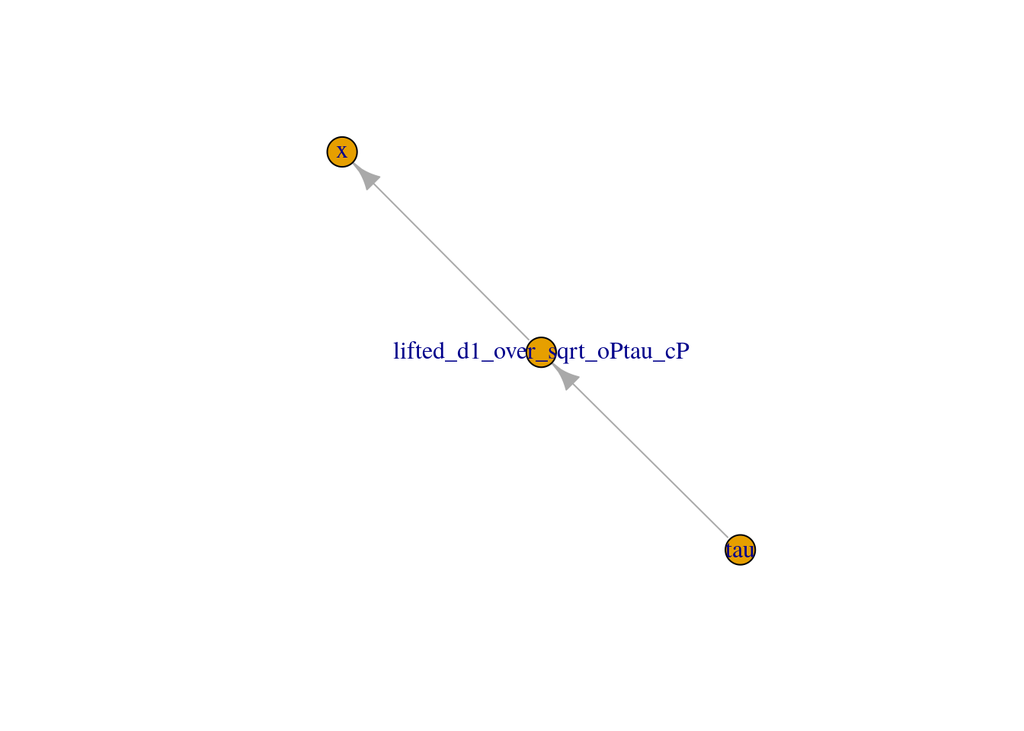

```r
par(mfrow = c(1,1
              ))
plot(m1$getGraph())
```

```r
m1$getNodeNames()
```

```
## [1] "tau"                          "lifted_d1_over_sqrt_oPtau_cP"
## [3] "x"
```

The node `lifted_d1_over_sqrt_oPtau_cP` has been inserted between `tau` and `x`. The resulting model would equivalently have been created by this BUGS code:

```r
nimbleCode({
    tau ~ dunif(0, 100)
    lifted_d1_over_sqrt_oPtau_cP <- 1/sqrt(tau)
    x ~ dnorm(0, sd = lifted_d1_over_sqrt_oPtau_cP) # override and make 2nd arg the SD
})
```

NIMBLE has *lifted* the calculation of standard deviation from precision so that it is part of the model’s graph. Therefore *you will make a mistake if you assume that the dependencies of `tau` include only `x`*:

```r
m1$tau <- 3
m1$x <- 1
m1$calculate(c('tau','x')) ## Wrong: the lifted node is being neglected
```

```
## [1] NA
```

Instead we need to ask NIMBLE for the dependencies of any nodes that have changed and use *model-generic* programming:

```r
deps <- m1$getDependencies('tau')
m1$tau <- 3
m1$x <- 1
m1$calculate(deps)
```

```
## [1] -6.474803
```

```r
deps
```

```
## [1] "tau"                          "lifted_d1_over_sqrt_oPtau_cP"
## [3] "x"
```

So the call to *calculate* causes the lifted node to get updated and then calculates the log probability density for *x*.